# report_sih_sus

### From lower to high-cost conditions: why ICSAP expenses keep growing.

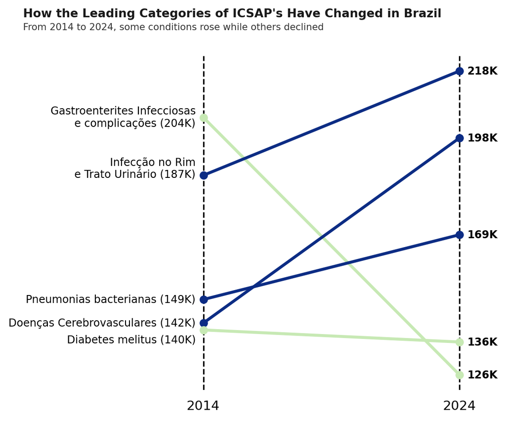

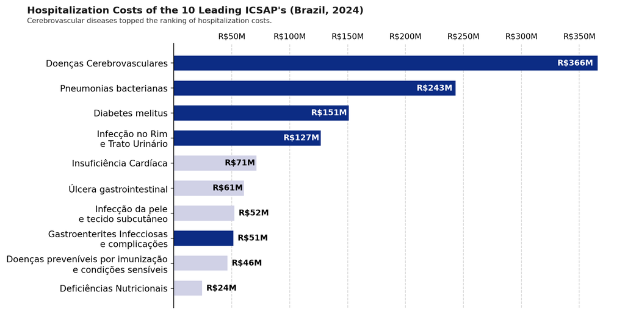

In 2014, the leading cause of ICSAP hospitalizations was infectious gastroenteritis (204k cases), a condition generally associated with lower treatment costs. After ten years, however, the profile of admissions had shifted: urinary tract infections (218k), **cerebrovascular diseases** (198k), and bacterial pneumonia (169k) became the most common causes. Unlike gastroenteritis, these conditions are among the most expensive categories of ICSAP. Cerebrovascular diseases alone accounted for more than **BRL 360 million** in 2024, followed by bacterial pneumonias with BRL 243 million.

This shift in the composition of hospitalizations helps explain why overall ICSAP costs continue to rise, even as the relative hospitalization rate has declined over the last decade.